# Featuring Engineering Practice

Machine Learning II

# Introduction

In this first practical session we will make the first contact with the featuring engineering process and its impact in a ML pipeline. Feature engineering is one of the most important step of the process of developing prediction models. It is considered, by many authors, an art, and it involves human-driven design and intuition. This practice will try to uncover the most relevant issues that must be addressed, and also provide some guidelines to start building sound feature engineering processes for ML problems.

The experimental dataset we are going to use is the HR Analytics Dataset. It includes explanatory variables of around 15k employees of a large company. The goal of the case study is to model the probability of attrition (employees leaving, either on their own or because they got fired) of each employee, as well as to understand which variables are the most important ones and need to be addressed right away.

The results obtained will be helpful for the management in order to understand what changes they should make to their workplace to get most of their employees to stay.

For more details on the dataset and the task see: https://www.kaggle.com/manojvijayan/feature-engineering-for-logistic-regression.

```r
## Importing packages
library(e1071)
library(caret)
library(ggplot2)
library(dplyr)
library(glmnet)
```

Some useful functions.

```r
# Train-Test Spliting
splitdf <- function(dataframe, seed=NULL) {
  if (!is.null(seed)) set.seed(seed)
    index <- 1:nrow(dataframe)
    trainindex <- sample(index, trunc(length(index)/1.5))
    trainset <- dataframe[trainindex, ]
    testset <- dataframe[-trainindex, ]
    list(trainset=trainset,testset=testset)
}
```

# Data Loading and Preprocessing

Let’s load the dataset to make sense of the information we have about the employees.

```r
# Note that you should modify the filepath according to where you have them
initial_hr_df<-read.csv("data/turnover.csv")
summary(initial_hr_df)
```

```
##  satisfaction_level last_evaluation  number_project  average_montly_hours
##  Min.   :0.0900     Min.   :0.3600   Min.   :2.000   Min.   : 96.0
##  1st Qu.:0.4400     1st Qu.:0.5600   1st Qu.:3.000   1st Qu.:156.0
##  Median :0.6400     Median :0.7200   Median :4.000   Median :200.0
##  Mean   :0.6128     Mean   :0.7161   Mean   :3.803   Mean   :201.1
##  3rd Qu.:0.8200     3rd Qu.:0.8700   3rd Qu.:5.000   3rd Qu.:245.0
##  Max.   :1.0000     Max.   :1.0000   Max.   :7.000   Max.   :310.0
##
##  time_spend_company Work_accident         left
##  Min.   : 2.000     Min.   :0.0000   Min.   :0.0000
##  1st Qu.: 3.000     1st Qu.:0.0000   1st Qu.:0.0000
##  Median : 3.000     Median :0.0000   Median :0.0000
##  Mean   : 3.498     Mean   :0.1446   Mean   :0.2381
##  3rd Qu.: 4.000     3rd Qu.:0.0000   3rd Qu.:0.0000
##  Max.   :10.000     Max.   :1.0000   Max.   :1.0000
##
##  promotion_last_5years         sales         salary
##  Min.   :0.00000       sales      :4140   high  :1237
##  1st Qu.:0.00000       technical  :2720   low   :7316
##  Median :0.00000       support    :2229   medium:6446
##  Mean   :0.02127       IT         :1227
##  3rd Qu.:0.00000       product_mng: 902
##  Max.   :1.00000       marketing  : 858
##                        (Other)    :2923
```

```r
# Keep the original dataset for later comparisons and make a copy for the FE process
hr_df <- data.frame(initial_hr_df)
```

We have 10 columns: the target variable (`left`) and 9 more features to work with. Let’s analyze a little bit more each of them to check if we need to clean or preprocess them.

## Factorize features

2 of the categories (`sales` and `salary`) are already categorical. In addition, if we analyze the rest of the features we will see that we have three more categorical values encoded as numeric: `Work_accident`, `promotion_last_5years` and the target variable itself (`left`). Therefore, we should convert them to categorical before any further processing.

You can use the `factor` function for the conversion and the `labels` parameter in case you want to redefine the names of the levels.

```r
hr_df$Work_accident <-factor(hr_df$Work_accident, levels = c("0", "1"), labels = c("No", "Yes"))
hr_df$promotion_last_5years <-factor(hr_df$promotion_last_5years, levels = c("0", "1"), labels = c("No", "Yes"))
hr_df$left <- factor(hr_df$left, levels = c("0", "1"), labels = c("No", "Yes"))
```

### Advanced Factorization

The rest of the numerical values present a level of detail that may be much more fine-grained than we need. For instance, the satisfaction level can be represented by different categories (low, medium, high, …). We will then create another “bucketized” feature for each of the numerical columns.

To that end, I will make use of two functions:

- **recode:** This function change the old values in the column by new ones. For more information on the `recode` function, please refer to: https://www.rdocumentation.org/packages/memisc/versions/0.99.14.12/topics/recode. I have applied this function to change discrete numerical values in `time_spend_company_cat` and `number_project_cat` to categories.
- **.bincode:** This function is a little bit trickier. It takes a numeric vector and a set of ranges and it “bucketizes” the vector according to the ranges. More information about this function: https://www.rdocumentation.org/packages/base/versions/3.5.2/topics/.bincode. I have used it to split the continuous numerical columns (`satisfaction_level`, `last_evaluation`, `average_montly_hours`) into levels. (Values taken from: https://www.kaggle.com/manojvijayan/feature-engineering-for-logistic-regression/notebook)

```r
hr_df$satisfaction_level_bin <-.bincode(hr_df$satisfaction_level, c(0, 0.11, 0.35, 0.46, 0.71, 0.92,1.0))
hr_df$last_evaluation_bin <-.bincode(hr_df$last_evaluation, c(0, 0.47, 0.48, 0.65, 0.88, 0.89,1.0))
hr_df$average_montly_hours_bin <-.bincode(hr_df$average_montly_hours, c(96, 131, 165, 178, 179, 259, 287, 320), TRUE, TRUE)

hr_df$number_project_cat <-recode(hr_df$number_project,`2`="Low",`3`="Low",`4`="Medium",`5`="Medium",`6`="High", `7`= "Very High")
hr_df$time_spend_company_cat <- recode(hr_df$time_spend_company,`2`="Low",`3`="Medium",`4`="Medium",`5`="Medium",`6`="High", `7`= "High", `8`= "Very High", `10`= "Very High")
```

## Hunting NAs

There is not any NULL values, so we can skip this step.

```r
# Missing values by column
colSums(is.na(hr_df))
```

```
##       satisfaction_level          last_evaluation           number_project
##                        0                        0                        0
##     average_montly_hours       time_spend_company            Work_accident
##                        0                        0                        0
##                     left    promotion_last_5years                    sales
##                        0                        0                        0
##                   salary   satisfaction_level_bin      last_evaluation_bin
##                        0                        0                        0
## average_montly_hours_bin       number_project_cat   time_spend_company_cat
##                        0                        0                        0
```

It is unlikely not to have any null values in the dataset (this is a reduced and rather clean dataset of the original one). In the case that you have null values, you should follow some of the imputation/removal strategies explained in class. Although `caret` (and some other libraries) provides ways to impute/remove the null values while training your model, I strongly recommend you to do it by yourself to control the process.

## Outlier Analysis

Another aspect that may affect the performance of our machine learning pipeline is the presence of outliers. We will focus on the numerical columns of the dataset to detect the presence of outliers and proceed to their removal.

The easiest way to detect outliers is visualizing the numerical values; for instance, by `boxploting` the column values.

For instance, if we plot the `time_spend_company` feature, we will see that there are some extreme cases of employees that have spent many years at the company.

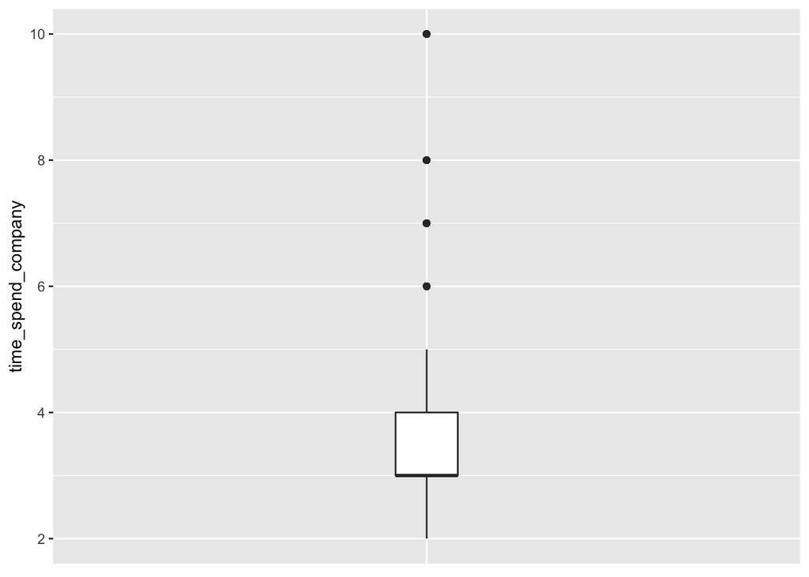

```r
ggplot(hr_df, aes(x="",y=time_spend_company))+ geom_boxplot(width=0.1) +
  theme(axis.line.x=element_blank(),axis.title.x=element_blank(), axis.ticks.x=element_blank(), axis.text.x=element_blank(),legend.position="none") # for a cleaner visualization
```

We don’t want these extreme cases to affect or bias the training process, so the best is to remove them. We can apply some metric (i.e., the Z-score) to detect and remove these points. The `boxplot.stats` function itself provides a way to remove them.

```r
# $out includes the outliers
to_remove <- boxplot.stats(hr_df$time_spend_company)$out
cat("Number of outliers", length(to_remove))
```

```
## Number of outliers 1282
```

```r
# Remove from the dataset the instances which time_spend_company value is among the outliers
hr_df <- hr_df[!hr_df$time_spend_company %in% to_remove, ]
```

Let’s do the same for the rest of the columns.

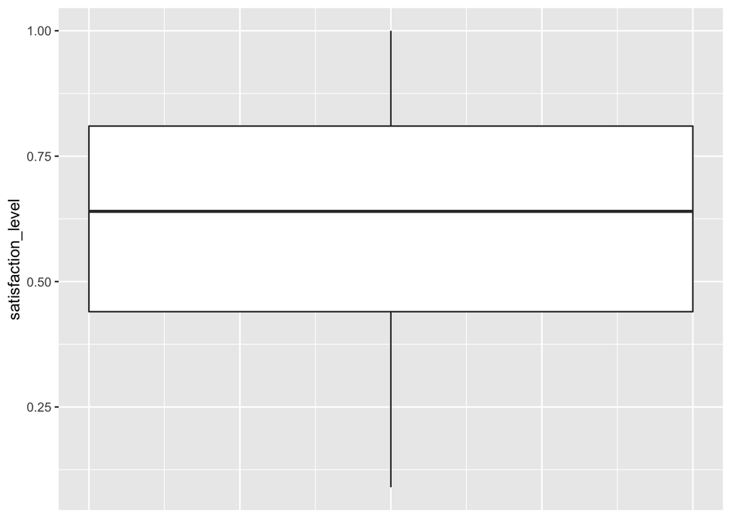

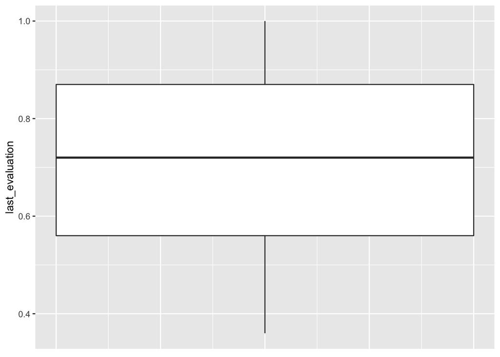

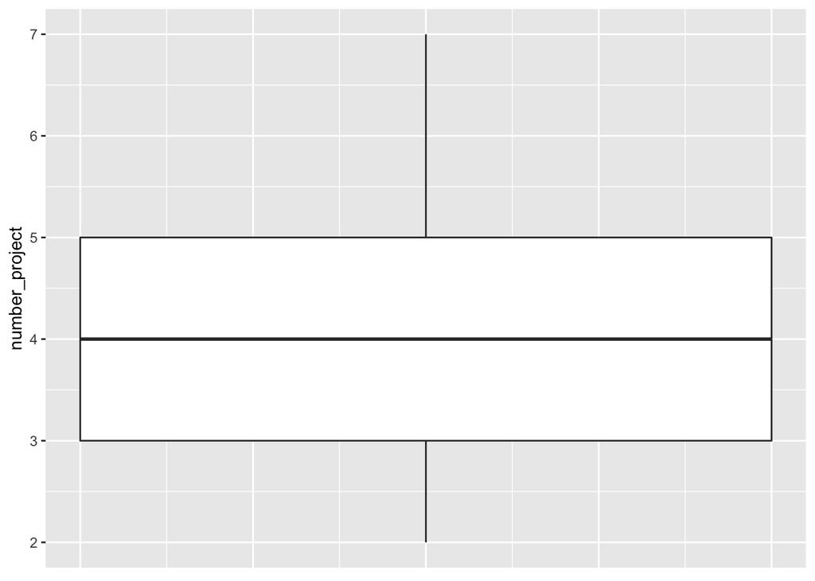

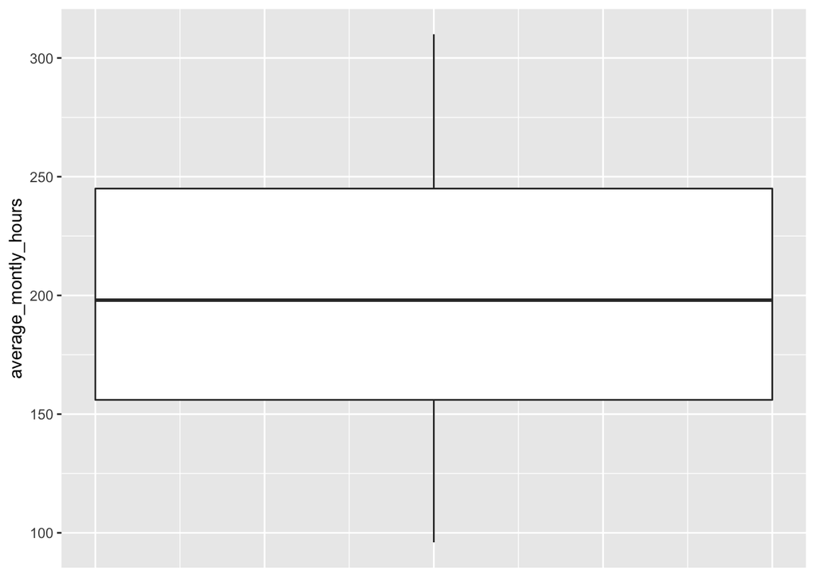

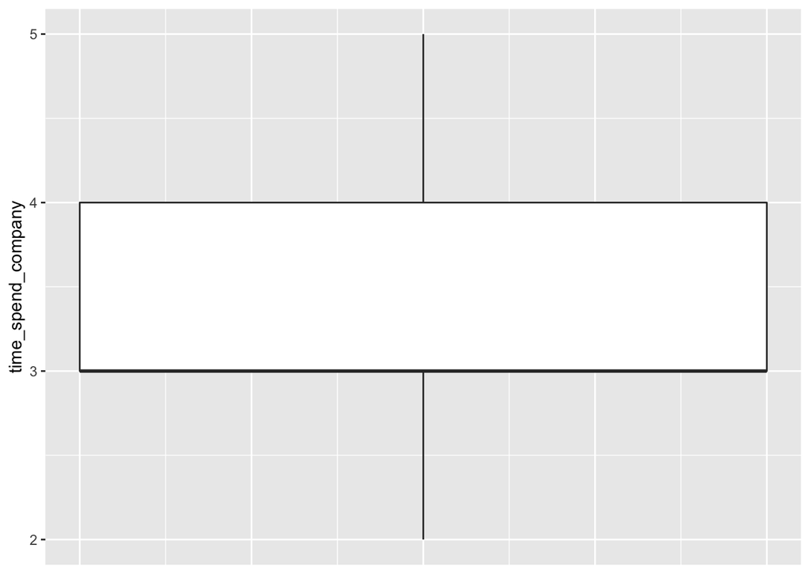

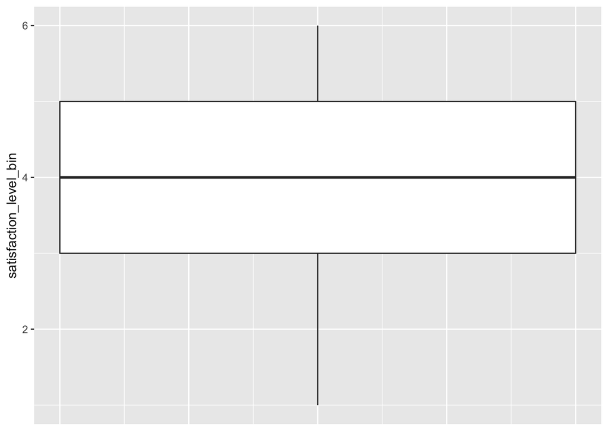

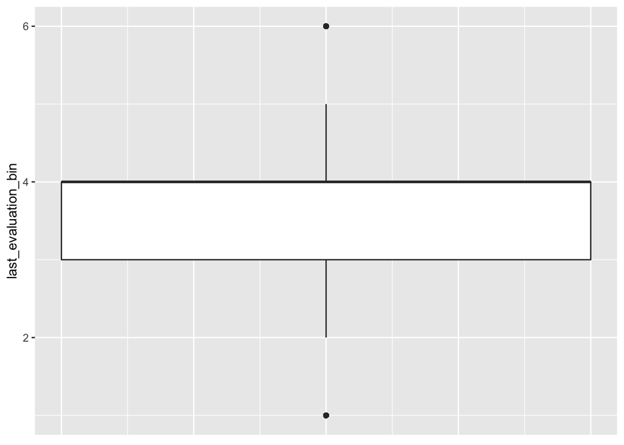

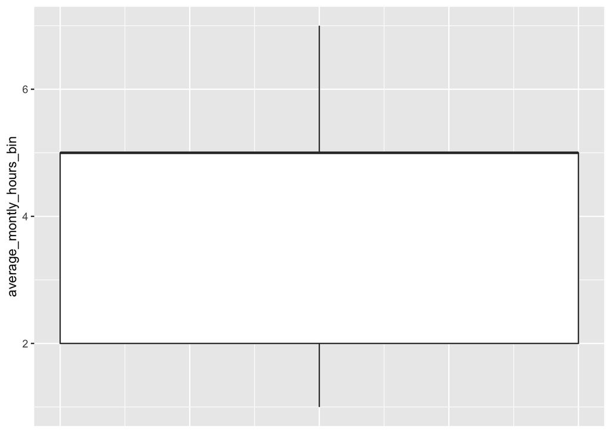

```r
for (col in names(hr_df)) { # Go over all the features
  if (is.numeric(hr_df[[col]]) && col != "left"){ # Take only the numerical features
    print(ggplot(hr_df, aes_string(y=col))+ geom_boxplot(width=0.1) + theme(axis.line.x=element_blank(),axis.title.x=element_blank(), axis.ticks.x=element_blank(), axis.text.x=element_blank(),legend.position="none")) # Boxplot
    to_remove <- boxplot.stats(hr_df[[col]])$out # Find outliers
    hr_df <- hr_df[!hr_df[[col]] %in% to_remove, ] # Remove Outliers
  }
}
```

# Train-Test Splitting

We are going to split the annotated dataset in training and test for the later evaluation of our ML models.

```r
# Original Dataset
initial_splits <- splitdf(initial_hr_df, seed=1)
initial_training <- initial_splits$trainset
initial_test <- initial_splits$testset

# Cleaned Dataset
splits <- splitdf(hr_df, seed=1)
training <- splits$trainset
test <- splits$testset
```

# Feature Engineering

We will fit a `glm` model to the initial dataset in order to have a baseline to evaluate the impact of the data cleaning and feature engineering.

To facilitate the training process we will use the `caret` package: http://topepo.github.io/caret/index.html. `caret` provides a wrapper for the preprocessing, training and evaluation of many machine learning algorithms. In particular, we will use the two main `caret` functions:

- **train():** Takes the training data, the model to be applied, and the evaluation metric to optimize and returns an object with the trained model. You can either plot the model to analyze it for its further refinement or use it for prediction:
- **predict():** Takes the trained model and the test set to predict the values of the target variable

```r
# Train
initial.lm.mod <- train(as.factor(left) ~ ., # Formula: Target variable ~ predictors
               data = initial_training, # Training data
               method = "glm", # ML model
               metric = "Accuracy" # Evaluation metric
               )

# Predict
initial.lm.mod.pred <- predict(initial.lm.mod, initial_test[,-which(names(initial_test) == "left")])

# Plot the confusion matrix
cm_initial <- confusionMatrix(initial.lm.mod.pred, as.factor(initial_test$left), positive = "1")
print(cm_initial)
```

```
## Confusion Matrix and Statistics
##
##           Reference
## Prediction    0    1
##          0 3568  790
##          1  256  386
##
##                Accuracy : 0.7908
##                  95% CI : (0.7793, 0.802)
##     No Information Rate : 0.7648
##     P-Value [Acc > NIR] : 6.122e-06
##
##                   Kappa : 0.31
##
##  Mcnemar's Test P-Value : < 2.2e-16
##
##             Sensitivity : 0.3282
##             Specificity : 0.9331
##          Pos Pred Value : 0.6012
##          Neg Pred Value : 0.8187
##              Prevalence : 0.2352
##          Detection Rate : 0.0772
##    Detection Prevalence : 0.1284
##       Balanced Accuracy : 0.6306
##
##        'Positive' Class : 1
##
```

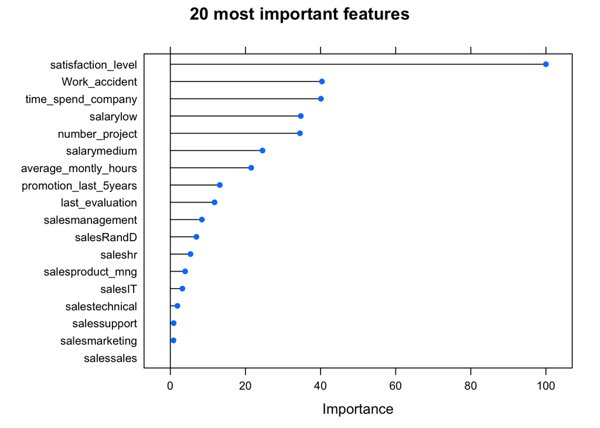

```r
# Plot the 20 most important features
plot(varImp(initial.lm.mod), main = "20 most important features")
```

And now the results with the cleaned dataset.

```r
# Train
full.lm.mod <- train(left ~ ., # Formula: Target variable ~ predictors
               data = training, # Training data
               method = "glm", # ML model
               metric = "Accuracy" # Evaluation metric
               )

# Predict
full.lm.mod.pred <- predict(full.lm.mod, test[,-which(names(test) == "left")])

# Plot the confusion matrix
cm <- confusionMatrix(full.lm.mod.pred, test$left, positive = "Yes")
print(cm)
```

```
## Confusion Matrix and Statistics
##
##           Reference
## Prediction   No  Yes
##        No  2501  181
##        Yes  142  569
##
##                Accuracy : 0.9048
##                  95% CI : (0.8944, 0.9145)
##     No Information Rate : 0.779
##     P-Value [Acc > NIR] : < 2e-16
##
##                   Kappa : 0.7183
##
##  Mcnemar's Test P-Value : 0.03448
##
##             Sensitivity : 0.7587
##             Specificity : 0.9463
##          Pos Pred Value : 0.8003
##          Neg Pred Value : 0.9325
##              Prevalence : 0.2210
##          Detection Rate : 0.1677
##    Detection Prevalence : 0.2095
##       Balanced Accuracy : 0.8525
##
##        'Positive' Class : Yes
##
```

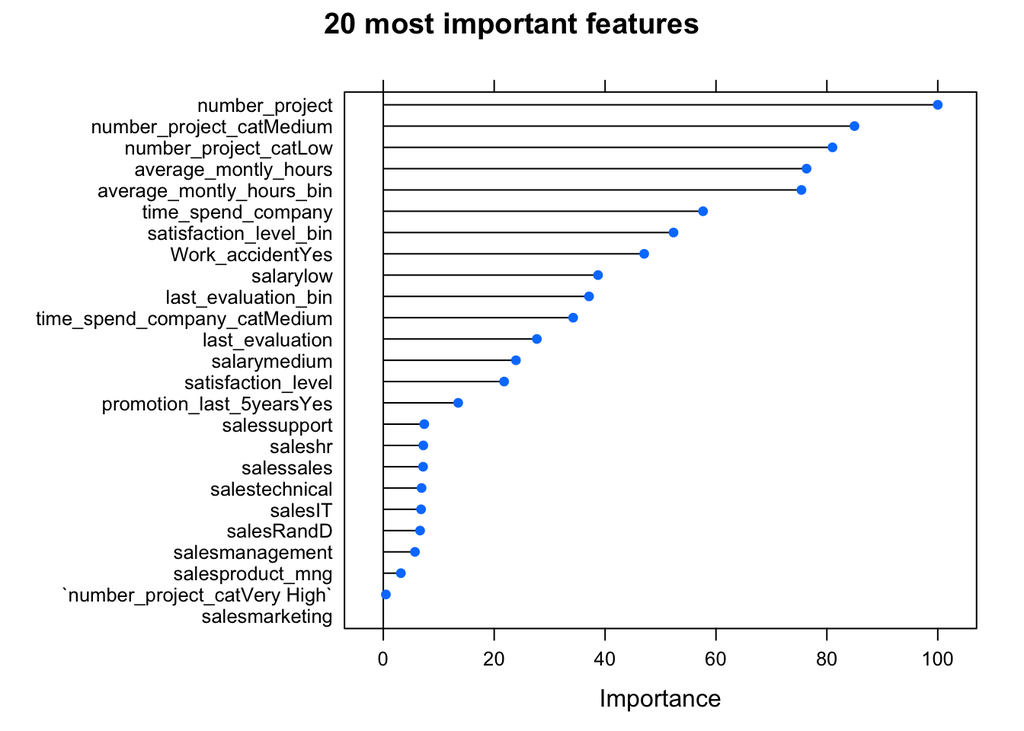

```r
# Plot the 20 most important features
plot(varImp(full.lm.mod), main = "20 most important features")
```

The analysis of the confusion matrix points out some interesting aspects:

- Even though we were dealing with a rather clean dataset, already prepared for experimentation, cleaning the dataset offers a huge improvement in the performance of the model.
- We have a global 90% of accuracy which seems a good results to be reported to the HR department.
- We are better at predicting the negative class (a employee is NOT going to leave the company) than the positive class (a employee is going to leave the company). **Why?**
- We can find some of the features that we have previously created among the most important features.

## Filtering Methods

We will rank the features according to their predictive power by applying the methodologies seen in class: the Chi Squared Independence test and the Information Gain.

Both Chi-squared and Information Gain are implemented by `FSelector` the package https://cran.r-project.org/web/packages/FSelector/FSelector.pdf. However, this package is well-known for having integration issues related to Java. If you are experiencing any problem **after having installed Java**, take a look to this link https://askubuntu.com/a/725386 to set your `LD_LIBRARY_PATH` to the path where you have Java installed.

Anyhow, if you have still problems with this package, do some research to find another packages (e.g., FSelectorRcpp).

### Chi-squared Selection

Making use of the `FSelector` package (or other you choice) rank the features according to the Chi Squared value.

Does it make sense to remove some features? If so, do it!

```r
# Your code here
```

#### Evaluation

Evaluate the impact of the feature selection.

To that end, execute the previous LM model taking as input the chi-squared-filtered training set.

```r
# Compute a new glm model with the new features and compute the new Accuracy to decide whether to keep the new variables or not.
```

### Information Gain Selection

Let’s experiment now with Information Gain Selection. Making use of the `FSelector` package (or other you choice), rank the features according to their Information Gain and filter those which you consider, according to the IG value.

```r
# Your code here.
```

#### Evaluation

Evaluate the impact of the IG selection in the model performance

```r
# Compute a new glm model with the new features and compute the new Accuracy to decide whether to keep the new variables or not.
```

### Exercise

Experiment with different cutoffs to filter the features and evaluate their impact in the performance. Select the cutoff that you consider more appropriate. Using the result of the evaluation, filter the dataset (according to the method and cutoff that you decide).

```r
# Your code here
```

## Wrapper Methods

Let us experiment with Wrapper Methods. In particular, we are going to apply Stepwise Selection Methods to find the best feature combination for this dataset.

### Stepwise

`caret` package provides a useful and easy way of experimenting with stepwise selection: take a look to the `glmStepAIC` method and its parameters (https://stat.ethz.ch/R-manual/R-devel/library/MASS/html/stepAIC.html); you can either use this method directly or in `caret` (`method = 'glmStepAIC'`).

Those methods are using **indirect techniques** to estimate what will be the error of your fit with the parameters selected, and that approach will always be more speculative than **direct techniques** based on cross validation. If we can use CV with stepwise, that’s a powerful method to select the best possible combination of features. But, that is not working very well in R, since most of the methods take ages to produce results or only work with factors with a maximum of two levels (`regsubsets` or `bestglm`).

Please, refer to these pages to know more about alternatives for doing stepwise selection:

A set of samples with the common packages used to accomplish stepwise selection. [Entry #1](https://rstudio-pubs-static.s3.amazonaws.com/2897_9220b21cfc0c43a396ff9abf122bb351.html)

This one covers what is the algorithmic approach to implement a good stepwise selection but using cross-validation, instead of relying on AIC or BIC. Very good if you want to implement your own method. [Entry #2](http://freakonometrics.hypotheses.org/19925)

This other is a paper indicating how to overcome the limitations of `bestglm` and is also interesting, though still has the **indirect**-like limitations. [Entry #3](https://www.ncbi.nlm.nih.gov/pmc/articles/PMC4842399/)

Since our dataset does not have a large set of features, we do not need to make use of any of these methods.

#### Backward Stepwise

Now, it is time to select what is the best possible compromise between the number of predictors and the results obtained. Firstly, we try backward stepwise.

```r
train_control_config_4_stepwise <- trainControl(method = "none", classProbs = TRUE)

# Your code here
```

Printout only the selected features.

```r
# Your code here
```

Evaluate the selected model

```r
# Your code here
```

#### Forward Stepwise

Try the same with forward stepwise.

```r
# Your code here
```

Printout only the selected features.

```r
# Your code here
```

Compute the new Accuracy

```r
# Your code here
```

### Exercise

Based on the results that you have achieved, filter the dataset by selecting the best set of features.

## Embedded

Finally, we will experiment with embedded methods. In particular we are going to focus on Ridge and Lasso Regularization.

### Ridge Regression

For this exercise, we are going to make use of the [`glmnet`](https://cran.r-project.org/web/packages/glmnet/index.html) library. Take a look to the library and fit a glmnet model making use of `caret` training function for Ridge Regression. To that end, use the following grid of lambda values.

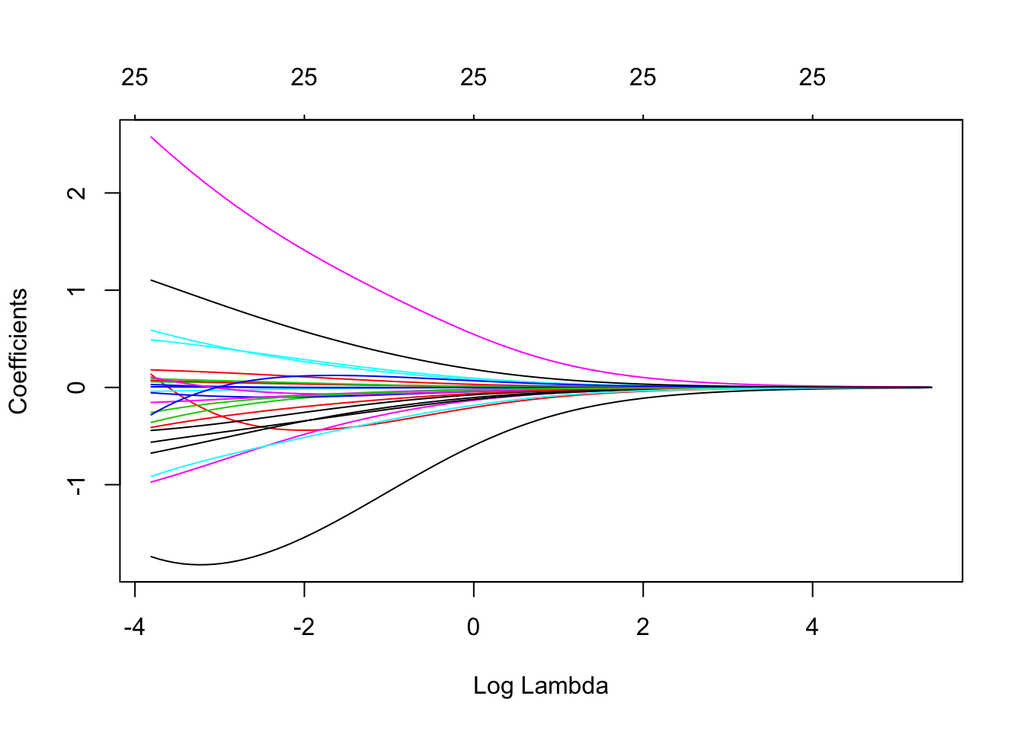

```r
lambdas <- 10^seq(-2, 1, by = .1)

ridge.mod <- train(left ~ ., data = training,
               method = "glmnet",
               metric = "Accuracy",
               tuneGrid = expand.grid(alpha = 0, lambda = lambdas))

plot(ridge.mod$finalModel, xvar = "lambda")
```

Select the best lambda and use it to predict the target value of the test set and evaluate the results.

```r
bestlam <- ridge.mod$bestTune['lambda']
paste("Best Lambda value from CV=", bestlam)
```

```
## [1] "Best Lambda value from CV= 0.0199526231496888"
```

```r
ridge.pred= predict(ridge.mod, s=bestlam, test[,-which(names(test) == "left")])
cm <- confusionMatrix(ridge.pred, test$left, positive = "Yes")
print(cm)
```

```
## Confusion Matrix and Statistics
##
##           Reference
## Prediction   No  Yes
##        No  2486  208
##        Yes  157  542
##
##                Accuracy : 0.8924
##                  95% CI : (0.8815, 0.9027)
##     No Information Rate : 0.779
##     P-Value [Acc > NIR] : < 2.2e-16
##
##                   Kappa : 0.6798
##
##  Mcnemar's Test P-Value : 0.008868
##
##             Sensitivity : 0.7227
##             Specificity : 0.9406
##          Pos Pred Value : 0.7754
##          Neg Pred Value : 0.9228
##              Prevalence : 0.2210
##          Detection Rate : 0.1597
##    Detection Prevalence : 0.2060
##       Balanced Accuracy : 0.8316
##
##        'Positive' Class : Yes
##
```

Ridge Regression offers similar results than unregularized models. If you remember from class, Ridge Regression does not remove any feature, it just forces the coefficients to take small values.

Rank the variables according to the importance attributed by the model to see this aspect.

```r
# Print, plot variable importance
imp <- varImp(ridge.mod$finalModel)
names <- rownames(imp)[order(imp$Overall, decreasing=TRUE)]
importance <- imp[names,]

data.frame(row.names = names, importance)
```

```
##                               importance
## number_project_catVery High  2.575429402
## satisfaction_level           1.739808588
## time_spend_company_catMedium 1.102754591
## Work_accidentYes             0.972781875
## number_project_catMedium     0.915086392
## promotion_last_5yearsYes     0.675275690
## salarylow                    0.588202852
## satisfaction_level_bin       0.563393400
## time_spend_company           0.490065931
## salesRandD                   0.442088676
## last_evaluation_bin          0.411221037
## number_project               0.359618184
## number_project_catLow        0.281223337
## average_montly_hours_bin     0.257738703
## saleshr                      0.180873564
## salesproduct_mng             0.154614861
## last_evaluation              0.134508425
## salarymedium                 0.106491826
## salessupport                 0.089949360
## salessales                   0.072585169
## salesIT                      0.059394477
## salesmanagement              0.054586956
## salesmarketing               0.038855364
## salestechnical               0.029634968
## average_montly_hours         0.006727104
```

### Lasso Regresion

Let’s see if Lasso (which actually removes features by making their coefficients equal to 0) improves the unregularized model.

Using again the [`glmnet`](https://cran.r-project.org/web/packages/glmnet/index.html) library and `caret`, fit a Lasso Regression (take a look to the alpha parameter) using the grid of lambda values provided.

```r
# Your code here
```

#### Evaluation

Select the best lambda form the CV model, use it to predict the target value of the test set and evaluate the results

```r
# Your code here
```

Take a look to the features selected by the lasso model (only those with importance larger than 0)

```r
# Your code here
```